# Prediction 2

Machine Learning

3 September 2021

# Workbook Intro

In this workbook we will cover:

- XGBoost
- Tuning XGBoost parameters
- XGBoost imbalanced data
- XGBoost variable importance
- Explainer plots
- Comparing model performance

# Set Up

First lets load the packages we will use for analysis.

```r
#install.packages("xgboost")
#install.packages("caret")
#install.packages("ggplot2")
#library(devtools)
#install_github("AppliedDataSciencePartners/xgboostExplainer")

library(xgboost) # Load XGBoost
library(caret) # Load Caret
library(ggplot2) # Load ggplot2
library(xgboostExplainer) # Load XGboost Explainer
library(pROC) # Load proc
library(SHAPforxgboost) # Load shap for XGBoost
library(data.table)
```

# Data Introduction

For this analysis we are going to use financial data similar to what we used for the previous assignment. The data is stored as `financial_data_pred.rda`.First lets load our data into the environment:

```r
load("financial_data_pred.rda") # Load dataset
```

Here the dataset has already been split into two parts with `train_data` containing 8,000 samples and `test_data` containing the 2,000 samples. There are 221 variables in the dataset, the response variable we will use for this analysis is `class` which is a binary variable with 1 indicating an increase in value and 0 indicating a decrease in value.

We can view the rest of the variables present in the data by checking the column names:

```r
names(train_data) # Get names of dataset
```

```
##   [1] "Revenue"
##   [2] "Revenue.Growth"
##   [3] "Cost.of.Revenue"
##   [4] "Gross.Profit"
##   [5] "R.D.Expenses"
##   [6] "SG.A.Expense"
##   [7] "Operating.Expenses"
##   [8] "Operating.Income"
##   [9] "Interest.Expense"
##  [10] "Earnings.before.Tax"
##  [11] "Income.Tax.Expense"
##  [12] "Net.Income...Non.Controlling.int"
##  [13] "Net.Income...Discontinued.ops"
##  [14] "Net.Income"
##  [15] "Preferred.Dividends"
```

[output cut: 206 more lines]

We next want to check for missing values in the dataset, as we have a high number of variables in the dataset, instead of viewing the summary for each one we can check for the total number of missing values in our dataset by running `is.na()` on our dataset and summing the result:

```r
sum(is.na(train_data)) # Check missing training data
```

```
## [1] 0
```

```r
sum(is.na(test_data)) # Check missing test data
```

```
## [1] 0
```

From the above we can see that there are no missing values.

We next want to examine our response variables:

```r
summary(as.factor(train_data$class))
```

```
##    0    1
## 3428 4572
```

```r
summary(as.factor(test_data$class))
```

```
##    0    1
##  742 1258
```

We see that for the training data we have 3,428 stocks whose value decreased over the year and 4,572 whose value increased over the year, while for our test data we have 742 stocks whose value decreased and 1,258 whose value increased.

The dataset is already split into training and test sets so we can move onto running some models.

# XGBoost

XGBoost (eXtreme Gradient Boosting) is an efficient implementation of gradient boosting. It can be used for both classification and regression.

XGBoost works as follows:

1. - Create naive model
2. - Calculate the errors of the model
3. - Build a model predicting the errors/Re-weight incorrect samples and rebuild model
4. - Add model to ensemble
5. - Repeat steps 2-4 until model converges/number of trees

To make a prediction at each step all of the models are used in the ensemble.

### Preparing data for XGBoost

XGBoost cannot be just passed a dataframe, instead it requires the data to be in matrix format:

- A matrix is a data frame that only contains numbers
- Convert categorical variables to dummy variables for use in a matrix.
- Numerical data includes both variables with numbers and TRUE/FALSE (1/0) variables

#### Convert data to DMatrix

XGBoost uses its own data type called DMatrix that is an efficient method for storing sparse matrices (Many zeros).

```r
# Create training matrix
dtrain <- xgb.DMatrix(data = as.matrix(train_data[, 1:220]), label = as.numeric(train_data$class) -1)
# Create test matrix
dtest <- xgb.DMatrix(data = as.matrix(test_data[, 1:220]), label = as.numeric(test_data$class) - 1)
```

### Training an XGBoost Model

Next we want to train our XGBoost model. For this XGBoost needs to have:

- Training data - The data we want to train our model on
- Number of Rounds - The number of rounds of training to use/Iterations/Trees
- Objective Function - This determines the output of XGBoost and is determined by the response variable we are using. Here as we have a binary response variable we choose the objective `binary:logistic`. By default XGBoost predicts a numerical response.

```r
set.seed(111111)
bst_1 <- xgboost(data = dtrain, # Set training data

               nrounds = 100, # Set number of rounds

               verbose = 1, # 1 - Prints out fit
                print_every_n = 20, # Prints out result every 20th iteration

               objective = "binary:logistic", # Set objective
               eval_metric = "auc",
               eval_metric = "error") # Set evaluation metric to use
```

### Predicting with XGBoost

To predict with XGBoost we can use the `predict()` function which we have used for other models. Let’s use a cutoff value of 0.5 and see how we do.

```r
boost_preds_1 <- predict(bst_1, dtest) # Create predictions for xgboost model

pred_dat <- cbind.data.frame(boost_preds_1 , test_data$class)#
# Convert predictions to classes, using optimal cut-off
boost_pred_class <- rep(0, length(boost_preds_1))
boost_pred_class[boost_preds_1 >= 0.5] <- 1


t <- table(boost_pred_class, test_data$class) # Create table
confusionMatrix(t, positive = "1") # Produce confusion matrix
```

```
## Confusion Matrix and Statistics
##
##
## boost_pred_class   0   1
##                0 385 462
##                1 357 796
##
##                Accuracy : 0.5905
##                  95% CI : (0.5686, 0.6122)
##     No Information Rate : 0.629
##     P-Value [Acc > NIR] : 0.999819
##
##                   Kappa : 0.1473
##
##  Mcnemar's Test P-Value : 0.000279
##
##             Sensitivity : 0.6328
##             Specificity : 0.5189
##          Pos Pred Value : 0.6904
##          Neg Pred Value : 0.4545
##              Prevalence : 0.6290
##          Detection Rate : 0.3980
##    Detection Prevalence : 0.5765
##       Balanced Accuracy : 0.5758
##
##        'Positive' Class : 1
##
```

### Tuning with XGBoost

There are several parameters which we can tune for XGBoost:

- max.depth - The depth of our trees (Maximum number of interactions to consider). (Values: 3-10)
- nrounds - The number of rounds to train the model. (Values: Aim for about 100 trees)
- eta - The learning rate of the model. (Values: 0.01 - 0.3)
- gamma - Minimum loss reduction necessary to make a further partition in a node.
- min_child_weight - Minimum sum of weight samples necessary to partition a node (Think of as minimum number of samples but weighted by value that ensemble gets incorrect). (Values: Highly problem specific)
- subsample - The ratio of the training data to use in each tree (Bootstrap samples). (Values: 0.5 - 1)
- colsample_bytree - The ratio of columns to sample for each tree (Like random forest but per tree not split) (Values: 0.5 - 1)
- early_stopping_rounds - Triggers the model to stop fitting if the performance has not increased for this number of rounds. We can use this to stop the tree growing early and decide optimal number of trees.

Fro XGBoost a good parameter tuning approach to take is:

- Choose a relatively high learning rate from 0.05 to 0.3. A value of 0.1 generally works best. Determine the optimum number of trees for this learning rate.
- Tune tree specific parameters such as max.depth, min_child_weight, gamma, subsample, colsample_bytree for decided learning rate and number of trees.
- Lower the learning rate and decide optimal number of trees.

Lets run our algorithm with a high number of trees and a learning rate of 0.1 to determine an appropriate number of trees to use.

```r
# Use xgb.cv to run cross-validation inside xgboost
set.seed(111111)
bst <- xgb.cv(data = dtrain, # Set training data

              nfold = 5, # Use 5 fold cross-validation

               eta = 0.1, # Set learning rate

               nrounds = 1000, # Set number of rounds
               early_stopping_rounds = 50, # Set number of rounds to stop at if there is no improvement

               verbose = 1, # 1 - Prints out fit
               nthread = 1, # Set number of parallel threads
               print_every_n = 20, # Prints out result every 20th iteration

               objective = "binary:logistic", # Set objective
               eval_metric = "auc",
               eval_metric = "error") # Set evaluation metric to use
```

```
## Multiple eval metrics are present. Will use test_error for early stopping.
## Will train until test_error hasn't improved in 50 rounds.
##
## Stopping. Best iteration:
```

From this we see 18 was the optimal number of iterations for our model. We use this number solely to ensure that we are doing a sufficient amount of rounds for our next tuning stages. We will set the number of iterations to 100 and include an early stop parameter of 20 for our next round of tuning. Next up we will tune max.depth and min_child_weight as these are likely to have the largest effect on model outcome.

```r
# Be Careful - This can take a very long time to run
max_depth_vals <- c(3, 5, 7, 10, 15) # Create vector of max depth values
min_child_weight <- c(1,3,5,7, 10, 15) # Create vector of min child values

# Expand grid of parameter values
cv_params <- expand.grid(max_depth_vals, min_child_weight)
names(cv_params) <- c("max_depth", "min_child_weight")
# Create results vector
auc_vec <- error_vec <- rep(NA, nrow(cv_params))
# Loop through results
for(i in 1:nrow(cv_params)){
  set.seed(111111)
  bst_tune <- xgb.cv(data = dtrain, # Set training data

              nfold = 5, # Use 5 fold cross-validation

              eta = 0.1, # Set learning rate
              max.depth = cv_params$max_depth[i], # Set max depth
              min_child_weight = cv_params$min_child_weight[i], # Set minimum number of samples in node to split


              nrounds = 100, # Set number of rounds
              early_stopping_rounds = 20, # Set number of rounds to stop at if there is no improvement

              verbose = 1, # 1 - Prints out fit
              nthread = 1, # Set number of parallel threads
              print_every_n = 20, # Prints out result every 20th iteration

              objective = "binary:logistic", # Set objective
              eval_metric = "auc", # Set evaluation metric to use
              eval_metric = "error") # Set evaluation metric to use
  auc_vec[i] <- bst_tune$evaluation_log$test_auc_mean[bst_tune$best_ntreelimit]
  error_vec[i] <- bst_tune$evaluation_log$test_error_mean[bst_tune$best_ntreelimit]

}
```

[output not shown]

[output cut: 84 more lines]

```
##
## Multiple eval metrics are present. Will use test_error for early stopping.
## Will train until test_error hasn't improved in 20 rounds.
##
## Stopping. Best iteration:
##
## Multiple eval metrics are present. Will use test_error for early stopping.
## Will train until test_error hasn't improved in 20 rounds.
##
## Stopping. Best iteration:
##
## Multiple eval metrics are present. Will use test_error for early stopping.
## Will train until test_error hasn't improved in 20 rounds.
##
## Stopping. Best iteration:
```

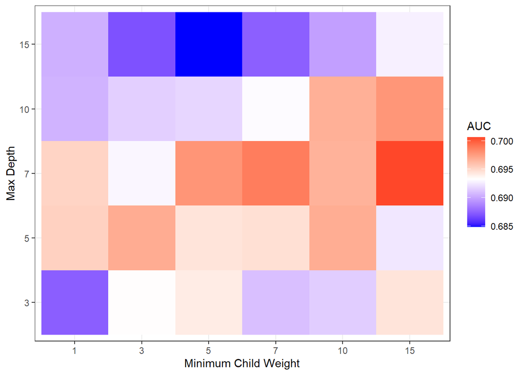

```r
# Join results in dataset
res_db <- cbind.data.frame(cv_params, auc_vec, error_vec)
names(res_db)[3:4] <- c("auc", "error")
res_db$max_depth <- as.factor(res_db$max_depth) # Convert tree number to factor for plotting
res_db$min_child_weight <- as.factor(res_db$min_child_weight) # Convert node size to factor for plotting
# Print AUC heatmap
g_2 <- ggplot(res_db, aes(y = max_depth, x = min_child_weight, fill = auc)) + # set aesthetics
  geom_tile() + # Use geom_tile for heatmap
  theme_bw() + # Set theme
  scale_fill_gradient2(low = "blue", # Choose low color
    mid = "white", # Choose mid color
    high = "red", # Choose high color
    midpoint =mean(res_db$auc), # Choose mid point
    space = "Lab",
    na.value ="grey", # Choose NA value
    guide = "colourbar", # Set color bar
    aesthetics = "fill") + # Select aesthetics to apply
  labs(x = "Minimum Child Weight", y = "Max Depth", fill = "AUC") # Set labels
g_2 # Generate plot
```

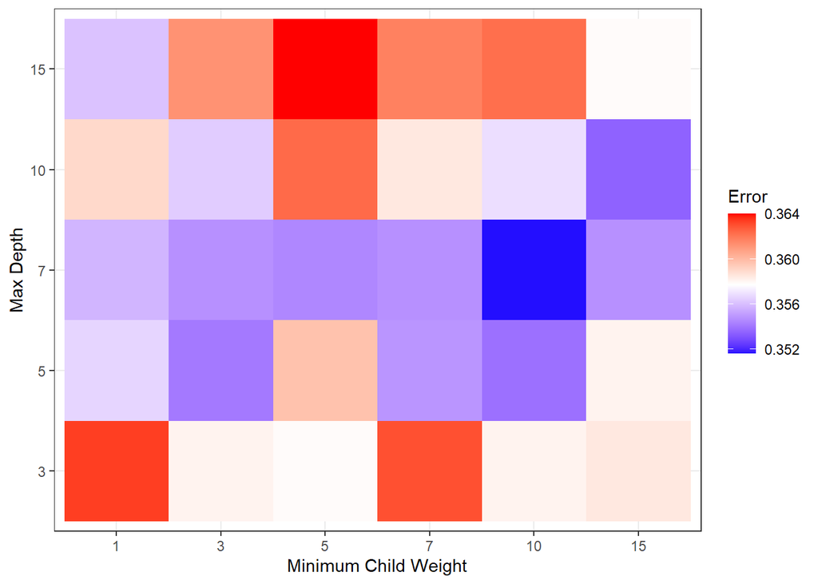

```r
# print error heatmap
g_3 <- ggplot(res_db, aes(y = max_depth, x = min_child_weight, fill = error)) + # set aesthetics
  geom_tile() + # Use geom_tile for heatmap
  theme_bw() + # Set theme
  scale_fill_gradient2(low = "blue", # Choose low color
    mid = "white", # Choose mid color
    high = "red", # Choose high color
    midpoint =mean(res_db$error), # Choose mid point
    space = "Lab",
    na.value ="grey", # Choose NA value
    guide = "colourbar", # Set color bar
    aesthetics = "fill") + # Select aesthetics to apply
  labs(x = "Minimum Child Weight", y = "Max Depth", fill = "Error") # Set labels
g_3 # Generate plot
```

We can also view the results for each set of the parameter combinations:

```r
res_db # Print results
```

```
##    max_depth min_child_weight       auc     error
## 1          3                1 0.6874266 0.3633746
## 2          5                1 0.6953398 0.3566236
## 3          7                1 0.6952086 0.3557498
## 4         10                1 0.6905456 0.3590002
## 5         15                1 0.6904428 0.3561250
## 6          3                3 0.6933724 0.3581268
## 7          5                3 0.6969562 0.3541248
## 8          7                3 0.6929936 0.3547484
## 9         10                3 0.6915842 0.3563764
## 10        15                3 0.6869610 0.3612484
## 11         3                5 0.6941444 0.3578750
## 12         5                5 0.6944978 0.3597476
## 13         7                5 0.6979020 0.3545020
## 14        10                5 0.6918436 0.3623764
```

[output cut: 16 more lines]

From this it appears our best set of results can from a max_depth value of 7 and a min child weight of 10 has the best performance for error while, a max depth value of 7 and min child weight of 15 has the highest AUC. From these we will select the value with the max depth of 7 and min child weight of 10 since the AUC values are quite close and there is more of a deviation in the error terms.

Next lets tune gamma, the minimum loss reduction necessary to make a further partition in a node.

```r
gamma_vals <- c(0, 0.05, 0.1, 0.15, 0.2) # Create vector of gamma values

# Be Careful - This can take a very long time to run
set.seed(111111)
auc_vec <- error_vec <- rep(NA, length(gamma_vals))
for(i in 1:length(gamma_vals)){
  bst_tune <- xgb.cv(data = dtrain, # Set training data

              nfold = 5, # Use 5 fold cross-validation

              eta = 0.1, # Set learning rate
              max.depth = 7, # Set max depth
              min_child_weight = 10, # Set minimum number of samples in node to split
              gamma = gamma_vals[i], # Set minimum loss reduction for split



              nrounds = 100, # Set number of rounds
              early_stopping_rounds = 20, # Set number of rounds to stop at if there is no improvement

              verbose = 1, # 1 - Prints out fit
              nthread = 1, # Set number of parallel threads
              print_every_n = 20, # Prints out result every 20th iteration

              objective = "binary:logistic", # Set objective
              eval_metric = "auc", # Set evaluation metric to use
              eval_metric = "error") # Set evaluation metric to use
  auc_vec[i] <- bst_tune$evaluation_log$test_auc_mean[bst_tune$best_ntreelimit]
  error_vec[i] <- bst_tune$evaluation_log$test_error_mean[bst_tune$best_ntreelimit]

}
```

```
## Multiple eval metrics are present. Will use test_error for early stopping.
## Will train until test_error hasn't improved in 20 rounds.
##
## Stopping. Best iteration:
##
## Multiple eval metrics are present. Will use test_error for early stopping.
## Will train until test_error hasn't improved in 20 rounds.
##
## Stopping. Best iteration:
##
## Multiple eval metrics are present. Will use test_error for early stopping.
## Will train until test_error hasn't improved in 20 rounds.
##
## Stopping. Best iteration:
##
## Multiple eval metrics are present. Will use test_error for early stopping.
## Will train until test_error hasn't improved in 20 rounds.
##
## Stopping. Best iteration:
##
## Multiple eval metrics are present. Will use test_error for early stopping.
## Will train until test_error hasn't improved in 20 rounds.
##
## Stopping. Best iteration:
```

Lets view our results to identify the value of gamma to use:

```r
# Join gamma to values
cbind.data.frame(gamma_vals, auc_vec, error_vec)
```

```
##   gamma_vals   auc_vec error_vec
## 1       0.00 0.6966652 0.3516244
## 2       0.05 0.6920832 0.3582526
## 3       0.10 0.6938564 0.3579994
## 4       0.15 0.6962456 0.3551260
## 5       0.20 0.6959244 0.3572496
```

Here it seems like a gamma value of 0 gives us the highest AUC value and lowest error rate.

Before we proceed lets re-calibrate the number of rounds to use for an optimal model here:

```r
# Use xgb.cv to run cross-validation inside xgboost
set.seed(111111)
bst <- xgb.cv(data = dtrain, # Set training data

              nfold = 5, # Use 5 fold cross-validation

              eta = 0.1, # Set learning rate
              max.depth = 7, # Set max depth
              min_child_weight = 10, # Set minimum number of samples in node to split
              gamma = 0, # Set minimum loss reduction for split


              nrounds = 1000, # Set number of rounds
              early_stopping_rounds = 50, # Set number of rounds to stop at if there is no improvement

              verbose = 1, # 1 - Prints out fit
              nthread = 1, # Set number of parallel threads
              print_every_n = 20, # Prints out result every 20th iteration

              objective = "binary:logistic", # Set objective
              eval_metric = "auc",
              eval_metric = "error") # Set evaluation metric to use
```

```
## Multiple eval metrics are present. Will use test_error for early stopping.
## Will train until test_error hasn't improved in 50 rounds.
##
## Stopping. Best iteration:
```

From this we see the optimal number of trees to use with our current set of parameters is 21 so we are still fitting an appropriate number of trees.

We will now tune the subsample and colsample_by_tree parameters

```r
# Be Careful - This can take a very long time to run
subsample <- c(0.6, 0.7, 0.8, 0.9, 1) # Create vector of subsample values
colsample_by_tree <- c(0.6, 0.7, 0.8, 0.9, 1) # Create vector of col sample values

# Expand grid of tuning parameters
cv_params <- expand.grid(subsample, colsample_by_tree)
names(cv_params) <- c("subsample", "colsample_by_tree")
# Create vectors to store results
auc_vec <- error_vec <- rep(NA, nrow(cv_params))
# Loop through parameter values
for(i in 1:nrow(cv_params)){
  set.seed(111111)
  bst_tune <- xgb.cv(data = dtrain, # Set training data

              nfold = 5, # Use 5 fold cross-validation

              eta = 0.1, # Set learning rate
              max.depth = 7, # Set max depth
              min_child_weight = 10, # Set minimum number of samples in node to split
              gamma = 0, # Set minimum loss reduction for split
              subsample = cv_params$subsample[i], # Set proportion of training data to use in tree
              colsample_bytree = cv_params$colsample_by_tree[i], # Set number of variables to use in each tree

              nrounds = 150, # Set number of rounds
              early_stopping_rounds = 20, # Set number of rounds to stop at if there is no improvement

              verbose = 1, # 1 - Prints out fit
              nthread = 1, # Set number of parallel threads
              print_every_n = 20, # Prints out result every 20th iteration

              objective = "binary:logistic", # Set objective
              eval_metric = "auc", # Set evaluation metric to use
              eval_metric = "error") # Set evaluation metric to use
  auc_vec[i] <- bst_tune$evaluation_log$test_auc_mean[bst_tune$best_ntreelimit]
  error_vec[i] <- bst_tune$evaluation_log$test_error_mean[bst_tune$best_ntreelimit]

}
```

[output not shown]

[output cut: 69 more lines]

```
##
## Multiple eval metrics are present. Will use test_error for early stopping.
## Will train until test_error hasn't improved in 20 rounds.
##
## Stopping. Best iteration:
##
## Multiple eval metrics are present. Will use test_error for early stopping.
## Will train until test_error hasn't improved in 20 rounds.
##
## Stopping. Best iteration:
##
## Multiple eval metrics are present. Will use test_error for early stopping.
## Will train until test_error hasn't improved in 20 rounds.
##
## Stopping. Best iteration:
```

We can now the visualize the result of tuning these parameters:

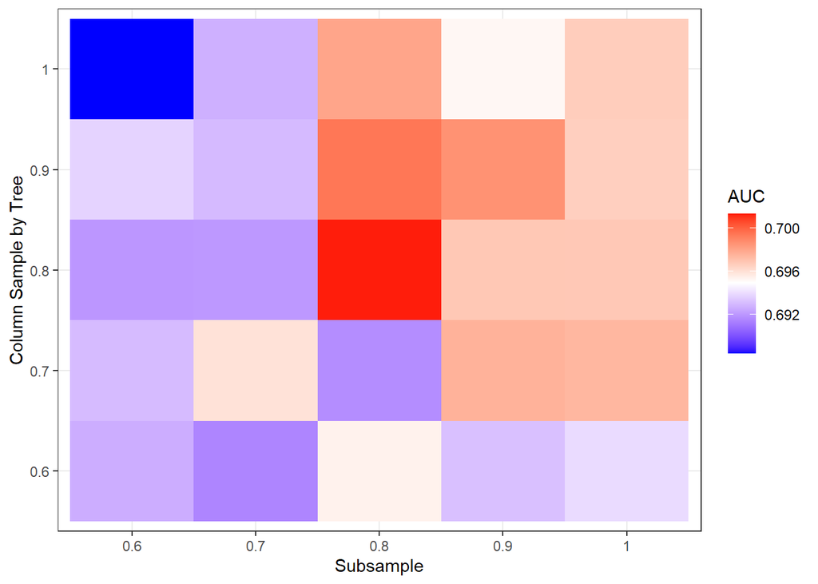

```r
res_db <- cbind.data.frame(cv_params, auc_vec, error_vec)
names(res_db)[3:4] <- c("auc", "error")
res_db$subsample <- as.factor(res_db$subsample) # Convert tree number to factor for plotting
res_db$colsample_by_tree <- as.factor(res_db$colsample_by_tree) # Convert node size to factor for plotting
g_4 <- ggplot(res_db, aes(y = colsample_by_tree, x = subsample, fill = auc)) + # set aesthetics
  geom_tile() + # Use geom_tile for heatmap
  theme_bw() + # Set theme
  scale_fill_gradient2(low = "blue", # Choose low color
    mid = "white", # Choose mid color
    high = "red", # Choose high color
    midpoint =mean(res_db$auc), # Choose mid point
    space = "Lab",
    na.value ="grey", # Choose NA value
    guide = "colourbar", # Set color bar
    aesthetics = "fill") + # Select aesthetics to apply
  labs(x = "Subsample", y = "Column Sample by Tree", fill = "AUC") # Set labels
g_4 # Generate plot
```

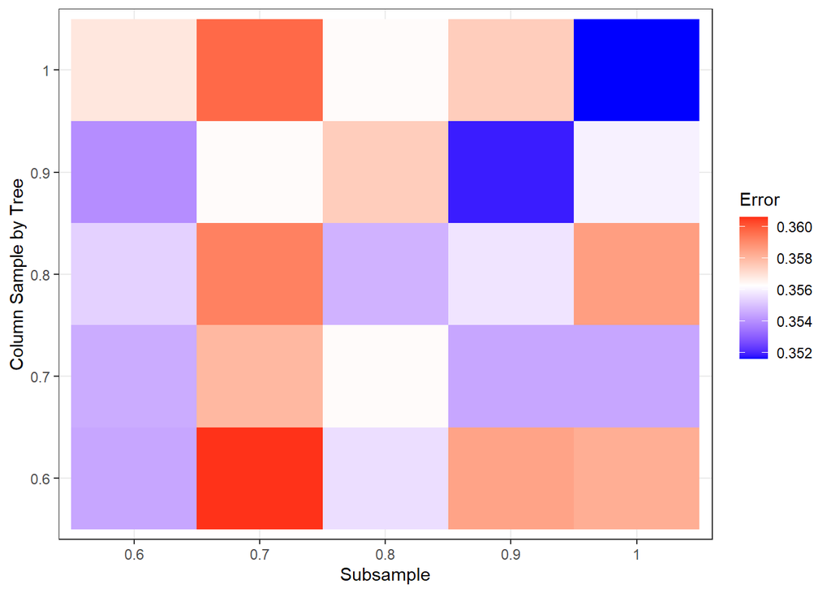

```r
g_5 <- ggplot(res_db, aes(y = colsample_by_tree, x = subsample, fill = error)) + # set aesthetics
  geom_tile() + # Use geom_tile for heatmap
  theme_bw() + # Set theme
  scale_fill_gradient2(low = "blue", # Choose low color
    mid = "white", # Choose mid color
    high = "red", # Choose high color
    midpoint =mean(res_db$error), # Choose mid point
    space = "Lab",
    na.value ="grey", # Choose NA value
    guide = "colourbar", # Set color bar
    aesthetics = "fill") + # Select aesthetics to apply
  labs(x = "Subsample", y = "Column Sample by Tree", fill = "Error") # Set labels
g_5 # Generate plot
```

```r
res_db
```

```
##    subsample colsample_by_tree       auc     error
## 1        0.6               0.6 0.6926392 0.3544972
## 2        0.7               0.6 0.6914956 0.3606254
## 3        0.8               0.6 0.6954016 0.3556240
## 4        0.9               0.6 0.6931968 0.3584990
## 5          1               0.6 0.6939678 0.3582484
## 6        0.6               0.7 0.6930650 0.3546230
## 7        0.7               0.7 0.6959466 0.3579998
## 8        0.8               0.7 0.6917236 0.3563732
## 9        0.9               0.7 0.6975620 0.3544994
## 10         1               0.7 0.6974024 0.3544988
## 11       0.6               0.8 0.6920062 0.3553728
## 12       0.7               0.8 0.6920640 0.3592506
## 13       0.8               0.8 0.7013196 0.3547476
## 14       0.9               0.8 0.6968464 0.3557508
## 15         1               0.8 0.6968326 0.3586204
## 16       0.6               0.9 0.6937386 0.3539982
## 17       0.7               0.9 0.6930344 0.3563754
## 18       0.8               0.9 0.6994326 0.3574976
## 19       0.9               0.9 0.6986080 0.3518750
## 20         1               0.9 0.6965940 0.3560000
## 21       0.6                 1 0.6884088 0.3568744
## 22       0.7                 1 0.6927406 0.3597486
## 23       0.8                 1 0.6980034 0.3563736
## 24       0.9                 1 0.6952196 0.3575014
## 25         1                 1 0.6966652 0.3516244
```

From this it looks like the optimal values of the parameters to use are a subsample parameter of 0.8-1 and a colsample_by_tree of 0.8-1. This indicates that the model in general performs better when more of the samples are included in the data. With low values performing much worse. This likely indicates that many of the variables in our dataset do not add much in terms of predictive power and trees built with these variables are poor predictors. We will select the middle values to use for our model with a subsample parameter of 0.9 and a colsample by tree of 0.9.

The final step in our tuning process is to lower the learning rate `eta` and add more trees, lets try a couple of different eta values here:

```r
# Use xgb.cv to run cross-validation inside xgboost
set.seed(111111)
bst_mod_1 <- xgb.cv(data = dtrain, # Set training data

              nfold = 5, # Use 5 fold cross-validation

              eta = 0.3, # Set learning rate
              max.depth = 7, # Set max depth
              min_child_weight = 10, # Set minimum number of samples in node to split
              gamma = 0, # Set minimum loss reduction for split
              subsample = 0.9, # Set proportion of training data to use in tree
              colsample_bytree =  0.9, # Set number of variables to use in each tree

              nrounds = 1000, # Set number of rounds
              early_stopping_rounds = 20, # Set number of rounds to stop at if there is no improvement

              verbose = 1, # 1 - Prints out fit
              nthread = 1, # Set number of parallel threads
              print_every_n = 20, # Prints out result every 20th iteration

              objective = "binary:logistic", # Set objective
              eval_metric = "auc",
              eval_metric = "error") # Set evaluation metric to use
```

```
## Multiple eval metrics are present. Will use test_error for early stopping.
## Will train until test_error hasn't improved in 20 rounds.
##
## Stopping. Best iteration:
```

```r
set.seed(111111)
bst_mod_2 <- xgb.cv(data = dtrain, # Set training data

              nfold = 5, # Use 5 fold cross-validation

              eta = 0.1, # Set learning rate
              max.depth =  7, # Set max depth
              min_child_weight = 10, # Set minimum number of samples in node to split
              gamma = 0, # Set minimum loss reduction for split
              subsample = 0.9 , # Set proportion of training data to use in tree
              colsample_bytree = 0.9, # Set number of variables to use in each tree

              nrounds = 1000, # Set number of rounds
              early_stopping_rounds = 20, # Set number of rounds to stop at if there is no improvement

              verbose = 1, # 1 - Prints out fit
              nthread = 1, # Set number of parallel threads
              print_every_n = 20, # Prints out result every 20th iteration

              objective = "binary:logistic", # Set objective
              eval_metric = "auc",
              eval_metric = "error") # Set evaluation metric to use
```

```
## Multiple eval metrics are present. Will use test_error for early stopping.
## Will train until test_error hasn't improved in 20 rounds.
##
## Stopping. Best iteration:
```

```r
set.seed(111111)
bst_mod_3 <- xgb.cv(data = dtrain, # Set training data

              nfold = 5, # Use 5 fold cross-validation

              eta = 0.05, # Set learning rate
              max.depth = 7, # Set max depth
              min_child_weight = 10 , # Set minimum number of samples in node to split
              gamma = 0, # Set minimum loss reduction for split
              subsample = 0.9 , # Set proportion of training data to use in tree
              colsample_bytree =  0.9, # Set number of variables to use in each tree

              nrounds = 1000, # Set number of rounds
              early_stopping_rounds = 20, # Set number of rounds to stop at if there is no improvement

              verbose = 1, # 1 - Prints out fit
              nthread = 1, # Set number of parallel threads
              print_every_n = 20, # Prints out result every 20th iteration

              objective = "binary:logistic", # Set objective
              eval_metric = "auc",
              eval_metric = "error") # Set evaluation metric to use
```

```
## Multiple eval metrics are present. Will use test_error for early stopping.
## Will train until test_error hasn't improved in 20 rounds.
##
## Stopping. Best iteration:
```

```r
set.seed(111111)
bst_mod_4 <- xgb.cv(data = dtrain, # Set training data

              nfold = 5, # Use 5 fold cross-validation

              eta = 0.01, # Set learning rate
              max.depth = 7, # Set max depth
              min_child_weight = 10, # Set minimum number of samples in node to split
              gamma = 0.1, # Set minimum loss reduction for split
              subsample = 0.9 , # Set proportion of training data to use in tree
              colsample_bytree = 0.9, # Set number of variables to use in each tree

              nrounds = 1000, # Set number of rounds
              early_stopping_rounds = 20, # Set number of rounds to stop at if there is no improvement

              verbose = 1, # 1 - Prints out fit
              nthread = 1, # Set number of parallel threads
              print_every_n = 20, # Prints out result every 20th iteration

              objective = "binary:logistic", # Set objective
              eval_metric = "auc",
              eval_metric = "error") # Set evaluation metric to use
```

```
## Multiple eval metrics are present. Will use test_error for early stopping.
## Will train until test_error hasn't improved in 20 rounds.
##
## Stopping. Best iteration:
```

```r
set.seed(111111)
bst_mod_5 <- xgb.cv(data = dtrain, # Set training data

              nfold = 5, # Use 5 fold cross-validation

              eta = 0.005, # Set learning rate
              max.depth = 7, # Set max depth
              min_child_weight = 10, # Set minimum number of samples in node to split
              gamma = 0, # Set minimum loss reduction for split
              subsample = 0.9 , # Set proportion of training data to use in tree
              colsample_bytree = 0.9, # Set number of variables to use in each tree

              nrounds = 1000, # Set number of rounds
              early_stopping_rounds = 20, # Set number of rounds to stop at if there is no improvement

              verbose = 1, # 1 - Prints out fit
              nthread = 1, # Set number of parallel threads
              print_every_n = 20, # Prints out result every 20th iteration

              objective = "binary:logistic", # Set objective
              eval_metric = "auc",
              eval_metric = "error") # Set evaluation metric to use
```

```
## Multiple eval metrics are present. Will use test_error for early stopping.
## Will train until test_error hasn't improved in 20 rounds.
##
## Stopping. Best iteration:
```

We can then plot the error rate over different learning rates:

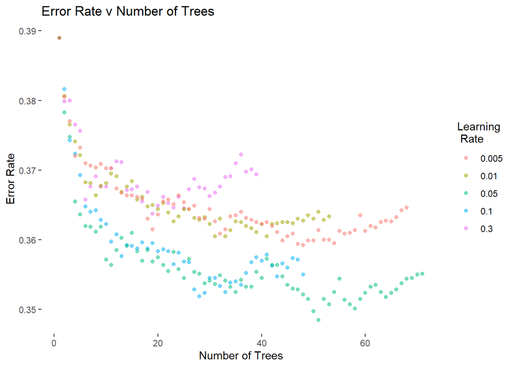

```r
# Extract results for model with eta = 0.3
pd1 <- cbind.data.frame(bst_mod_1$evaluation_log[,c("iter", "test_error_mean")], rep(0.3, nrow(bst_mod_1$evaluation_log)))
names(pd1)[3] <- "eta"
# Extract results for model with eta = 0.1
pd2 <- cbind.data.frame(bst_mod_2$evaluation_log[,c("iter", "test_error_mean")], rep(0.1, nrow(bst_mod_2$evaluation_log)))
names(pd2)[3] <- "eta"
# Extract results for model with eta = 0.05
pd3 <- cbind.data.frame(bst_mod_3$evaluation_log[,c("iter", "test_error_mean")], rep(0.05, nrow(bst_mod_3$evaluation_log)))
names(pd3)[3] <- "eta"
# Extract results for model with eta = 0.01
pd4 <- cbind.data.frame(bst_mod_4$evaluation_log[,c("iter", "test_error_mean")], rep(0.01, nrow(bst_mod_4$evaluation_log)))
names(pd4)[3] <- "eta"
# Extract results for model with eta = 0.005
pd5 <- cbind.data.frame(bst_mod_5$evaluation_log[,c("iter", "test_error_mean")], rep(0.005, nrow(bst_mod_5$evaluation_log)))
names(pd5)[3] <- "eta"
# Join datasets
plot_data <- rbind.data.frame(pd1, pd2, pd3, pd4, pd5)
# Converty ETA to factor
plot_data$eta <- as.factor(plot_data$eta)
# Plot points
g_6 <- ggplot(plot_data, aes(x = iter, y = test_error_mean, color = eta))+
  geom_point(alpha = 0.5) +
  theme_bw() + # Set theme
  theme(panel.grid.major = element_blank(), # Remove grid
        panel.grid.minor = element_blank(), # Remove grid
        panel.border = element_blank(), # Remove grid
        panel.background = element_blank()) + # Remove grid
  labs(x = "Number of Trees", title = "Error Rate v Number of Trees",
       y = "Error Rate", color = "Learning \n Rate")  # Set labels
g_6
```

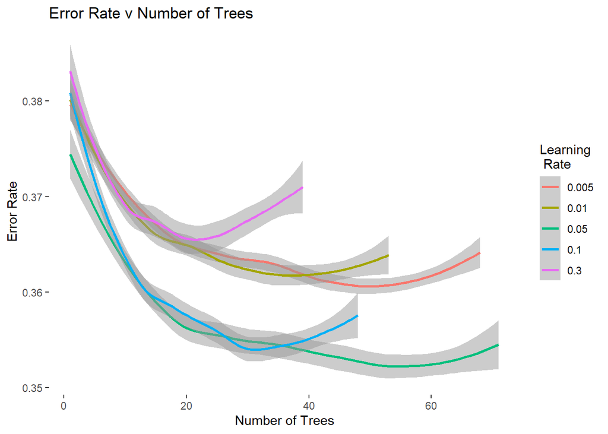

```r
# Plot lines
g_7 <- ggplot(plot_data, aes(x = iter, y = test_error_mean, color = eta))+
  geom_smooth(alpha = 0.5) +
  theme_bw() + # Set theme
  theme(panel.grid.major = element_blank(), # Remove grid
        panel.grid.minor = element_blank(), # Remove grid
        panel.border = element_blank(), # Remove grid
        panel.background = element_blank()) + # Remove grid
  labs(x = "Number of Trees", title = "Error Rate v Number of Trees",
       y = "Error Rate", color = "Learning \n Rate")  # Set labels
g_7
```

Here we are looking forthe line which reaches the lowest error rate. From this it looks like an eta value of 0.05 gives the best results for this dataset. We can now fit our final model using our tuned hyper parameters:

```r
set.seed(111111)
bst_final <- xgboost(data = dtrain, # Set training data



              eta = 0.05, # Set learning rate
              max.depth =  7, # Set max depth
              min_child_weight = 10, # Set minimum number of samples in node to split
              gamma = 0, # Set minimum loss reduction for split
              subsample =  0.9, # Set proportion of training data to use in tree
              colsample_bytree = 0.9, # Set number of variables to use in each tree

              nrounds = 100, # Set number of rounds
              early_stopping_rounds = 20, # Set number of rounds to stop at if there is no improvement

              verbose = 1, # 1 - Prints out fit
              nthread = 1, # Set number of parallel threads
              print_every_n = 20, # Prints out result every 20th iteration

              objective = "binary:logistic", # Set objective
              eval_metric = "auc",
              eval_metric = "error") # Set evaluation metric to use
```

```
## Multiple eval metrics are present. Will use train_error for early stopping.
## Will train until train_error hasn't improved in 20 rounds.
##
```

Now lets examine how our tuned model performs on our test dataset:

```r
boost_preds <- predict(bst_final, dtest) # Create predictions for XGBoost model

pred_dat <- cbind.data.frame(boost_preds , test_data$class)#
# Convert predictions to classes, using optimal cut-off
boost_pred_class <- rep(0, length(boost_preds))
boost_pred_class[boost_preds >= 0.5] <- 1


t <- table(boost_pred_class, test_data$class) # Create table
confusionMatrix(t, positive = "1") # Produce confusion matrix
```

```
## Confusion Matrix and Statistics
##
##
## boost_pred_class   0   1
##                0 368 401
##                1 374 857
##
##                Accuracy : 0.6125
##                  95% CI : (0.5907, 0.6339)
##     No Information Rate : 0.629
##     P-Value [Acc > NIR] : 0.9392
##
##                   Kappa : 0.1759
##
##  Mcnemar's Test P-Value : 0.3503
##
##             Sensitivity : 0.6812
##             Specificity : 0.4960
##          Pos Pred Value : 0.6962
##          Neg Pred Value : 0.4785
##              Prevalence : 0.6290
##          Detection Rate : 0.4285
##    Detection Prevalence : 0.6155
##       Balanced Accuracy : 0.5886
##
##        'Positive' Class : 1
##
```

For the final model we have an accuracy of 0.6125. Thus we have improved our performance from our initial model which had an accuracy of 0.5905.

### Imbalanced data with XGBoost

One of the options for XGBoost when dealing with imbalanced data is to scale the weights for each of the samples to account for the imbalanced data. This isn’t a very imbalanced dataset but to demonstrate the method we will use it anyway.

Lets first check the number of samples we have for each class in the training data:

```r
summary(as.factor(train_data$class))
```

```
##    0    1
## 3428 4572
```

We will then create a weight which we can use to scale the positive class weight so that we have equal representation in the dataset in terms of initial weights:

```r
zero_weight <- 3428/4572 # Calculate proportion of positive samples in data
```

```r
set.seed(111111)
bst_bal <- xgboost(data = dtrain, # Set training data



              eta = 0.05, # Set learning rate
              max.depth =  7, # Set max depth
              min_child_weight = 10, # Set minimum number of samples in node to split
              gamma = 0, # Set minimum loss reduction for split
              subsample =  0.9, # Set proportion of training data to use in tree
              colsample_bytree = 0.9, # Set number of variables to use in each tree

              nrounds = 200, # Set number of rounds
              early_stopping_rounds = 20, # Set number of rounds to stop at if there is no improvement

              verbose = 1, # 1 - Prints out fit
              nthread = 1, # Set number of parallel threads
              print_every_n = 20, # Prints out result every 20th iteration

              scale_pos_weight = zero_weight, # Set weights

              objective = "binary:logistic", # Set objective
              eval_metric = "auc",
              eval_metric = "error") # Set evaluation metric to use
```

```
## Multiple eval metrics are present. Will use train_error for early stopping.
## Will train until train_error hasn't improved in 20 rounds.
##
```

```r
# Check results
boost_preds_bal <- predict(bst_bal, dtest) # Create predictions for XGBoost model

pred_dat <- cbind.data.frame(boost_preds_bal , test_data$class)#
# Convert predictions to classes, using optimal cut-off
boost_pred_class <- rep(0, length(boost_preds_bal))
boost_pred_class[boost_preds_bal >= 0.5] <- 1


t <- table(boost_pred_class, test_data$class) # Create table
confusionMatrix(t, positive = "1") # Produce confusion matrix
```

```
## Confusion Matrix and Statistics
##
##
## boost_pred_class   0   1
##                0 473 571
##                1 269 687
##
##                Accuracy : 0.58
##                  95% CI : (0.558, 0.6018)
##     No Information Rate : 0.629
##     P-Value [Acc > NIR] : 1
##
##                   Kappa : 0.1694
##
##  Mcnemar's Test P-Value : <2e-16
##
##             Sensitivity : 0.5461
##             Specificity : 0.6375
##          Pos Pred Value : 0.7186
##          Neg Pred Value : 0.4531
##              Prevalence : 0.6290
##          Detection Rate : 0.3435
##    Detection Prevalence : 0.4780
##       Balanced Accuracy : 0.5918
##
##        'Positive' Class : 1
##
```

For the balanced model we have a balanced accuracy of 0.5918 and an overall accuracy of 0.58. So our balanced accuracy has improved while our overall accuracy went down slightly.

### Variable Importance with XGBoost

Similar to bagging and random forests we can extract importance measures from XGBoost:

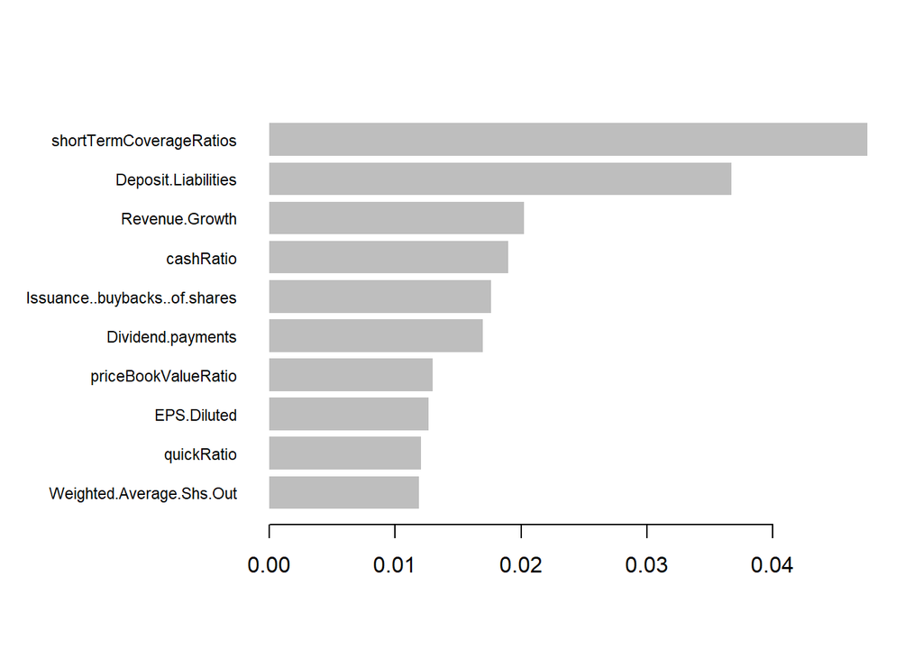

```r
# Extract importance
imp_mat <- xgb.importance(model = bst_final)
# Plot importance (top 10 variables)
xgb.plot.importance(imp_mat, top_n = 10)
```

### SHAP (SHapley Additive exPlanation)

SHAP values attribute to each feature the change in expected model prediction when conditioning on that features. They can be used to explain how each of the predictions was reached in an additive fashion. They have several other properties that make them desirable to be used as a feature importance measure over impurity. `http://papers.nips.cc/paper/7062-a-unified-approach-to-interpreting-model-predictions.pdf`

One of the benefits of SHAP is that we can use the values to decompose a single prediction and identify the variables which contributed to that prediction.

```r
getTreeBreakdown = function(tree, col_names){

  ####accepts a tree (data table), and column names
  ####outputs a data table, of the impact of each variable + intercept, for each leaf

  tree_breakdown <- vector("list", length(col_names)  + 2)
  names(tree_breakdown) = c(col_names,'intercept','leaf')

  leaves = tree[leaf==T, Node]

  for (leaf in leaves){

    leaf_breakdown = getLeafBreakdown(tree,leaf,col_names)
    leaf_breakdown$leaf = leaf
    tree_breakdown = rbindlist(append(list(tree_breakdown),list(leaf_breakdown)))
  }

  return (tree_breakdown)
}
```

```r
buildExplainerFromTreeList = function(tree_list,col_names){

  ####accepts a list of trees and column names
  ####outputs a data table, of the impact of each variable + intercept, for each leaf

  tree_list_breakdown <- vector("list", length(col_names)  + 3)
  names(tree_list_breakdown) = c(col_names,'intercept', 'leaf','tree')

  num_trees = length(tree_list)

  cat('\n\nGetting breakdown for each leaf of each tree...\n')
  pb <- txtProgressBar(style=3)

  for (x in 1:num_trees){
    tree = tree_list[[x]]
    tree_breakdown = getTreeBreakdown(tree, col_names)
    tree_breakdown$tree = x - 1
    tree_list_breakdown = rbindlist(append(list(tree_list_breakdown),list(tree_breakdown)))
    setTxtProgressBar(pb, x / num_trees)
  }

  return (tree_list_breakdown)

}
```

```r
getStatsForTrees = function(trees, nodes.train, type = "binary", base_score = 0.5){
  #Accepts data table of tree (the output of xgb.model.dt.tree)
  #Returns a list of tree, with the stats filled in

  tree_list = copy(trees)
  tree_list[,leaf := Feature == 'Leaf']
  tree_list[,H:=Cover]

  non.leaves = which(tree_list[,leaf]==F)


  # The default cover (H) seems to lose precision so this loop recalculates it for each node of each tree
  cat('\n\nRecalculating the cover for each non-leaf... \n')
  pb <- txtProgressBar(style=3)
  j = 0
  for (i in rev(non.leaves)){
    left = tree_list[i,Yes]
    right = tree_list[i,No]
    tree_list[i,H:=tree_list[ID==left,H] + tree_list[ID==right,H]]
    j=j+1
    setTxtProgressBar(pb, j / length(non.leaves))
  }


  if (type == 'regression'){
    base_weight = base_score
  } else{
    base_weight = log(base_score / (1-base_score))
  }

  tree_list[leaf==T,weight:=base_weight + Quality]

  tree_list[,previous_weight:=base_weight]
  tree_list[1,previous_weight:=0]

  tree_list[leaf==T,G:=-weight*H]

  tree_list = split(tree_list,as.factor(tree_list$Tree))
  num_tree_list = length(tree_list)
  treenums =  as.character(0:(num_tree_list-1))
  t = 0
  cat('\n\nFinding the stats for the xgboost trees...\n')
  pb <- txtProgressBar(style=3)
  for (tree in tree_list){
    t=t+1
    num_nodes = nrow(tree)
    non_leaf_rows = rev(which(tree[,leaf]==F))
    for (r in non_leaf_rows){
        left = tree[r,Yes]
        right = tree[r,No]
        leftG = tree[ID==left,G]
        rightG = tree[ID==right,G]

        tree[r,G:=leftG+rightG]
        w=tree[r,-G/H]

        tree[r,weight:=w]
        tree[ID==left,previous_weight:=w]
        tree[ID==right,previous_weight:=w]
    }

    tree[,uplift_weight:=weight-previous_weight]
    setTxtProgressBar(pb, t / num_tree_list)
  }

  return (tree_list)
}
```

```r
getLeafBreakdown = function(tree,leaf,col_names){

  ####accepts a tree, the leaf id to breakdown and column names
  ####outputs a list of the impact of each variable + intercept

  impacts = as.list(rep(0,length(col_names)))
  names(impacts) = col_names

  path = findPath(tree,leaf)
  reduced_tree = tree[Node %in% path,.(Feature,uplift_weight)]

  impacts$intercept=reduced_tree[1,uplift_weight]
  reduced_tree[,uplift_weight:=shift(uplift_weight,type='lead')]

  tmp = reduced_tree[,.(sum=sum(uplift_weight)),by=Feature]
  tmp = tmp[-nrow(tmp)]
  impacts[tmp[,Feature]]=tmp[,sum]

  return (impacts)
}
```

```r
findPath = function(tree, currentnode, path = c()){

  #accepts a tree data table, and the node to reach
  #path is used in the recursive function - do not set this

  while(currentnode>0){
    path = c(path,currentnode)
    currentlabel = tree[Node==currentnode,ID]
    currentnode = c(tree[Yes==currentlabel,Node],tree[No==currentlabel,Node])
  }
  return (sort(c(path,0)))

}
```

```r
findLeaves = function(tree, currentnode){

  if (tree[currentnode,'Feature']=='Leaf'){
    leaves = currentnode
  }else{
    leftnode = tree[currentnode,Yes]
    rightnode = tree[currentnode,No]
    leaves = c(findLeaves(tree,'leftnode',with=FALSE),findLeaves(tree,'rightnode',with=FALSE))
  }

  return (sort(leaves))


}
```

```r
buildExplainer = function(xgb.model,
                          trainingData,

                          type = "binary", base_score = 0.5, trees_idx = NULL){

  col_names = colnames(trainingData)
  cat('\nCreating the trees of the xgboost model...')
  trees = xgb.model.dt.tree(col_names, model = xgb.model, trees = trees_idx)
  cat('\nGetting the leaf nodes for the training set observations...')
  nodes.train = predict(xgb.model,trainingData,predleaf =TRUE)

  cat('\nBuilding the Explainer...')
  cat('\nSTEP 1 of 2')
  tree_list = getStatsForTrees(trees, nodes.train, type = type, base_score = base_score)
  cat('\n\nSTEP 2 of 2')
  explainer = buildExplainerFromTreeList(tree_list,col_names)

  cat('\n\nDONE!\n\n')

  return (explainer)
}
```

# Add explainer

```r
explainer = buildExplainer(bst_final, dtrain, type="binary", base_score = 0.5, trees_idx = NULL) # Create explainer
```

```
##
## Creating the trees of the xgboost model...
## Getting the leaf nodes for the training set observations...
## Building the Explainer...
## STEP 1 of 2
##
## Recalculating the cover for each non-leaf...
##
##
## Finding the stats for the xgboost trees...
##
##
## STEP 2 of 2
##
## Getting breakdown for each leaf of each tree...
##
##
## DONE!
```

```r
pred.breakdown = explainPredictions(bst_final, explainer, dtest) # Breakdown predictions
```

```
##
##
## Extracting the breakdown of each prediction...
##
##
## DONE!
```

```r
# Create explainer for sample 1441
showWaterfall(bst_final, explainer, dtest, as.matrix(test_data[, 1:220]) ,1441, type = "binary", threshold = 0.07)
```

```
##
##
## Extracting the breakdown of each prediction...
##
##
## DONE!
##
## Actual:  0
## Prediction:  0.5698293
## Weight:  0.2811547
## Breakdown
##               intercept shortTermCoverageRatios      priceCashFlowRatio
##              0.30175693              0.12750471             -0.10932842
##     Deposit.Liabilities       Dividend.payments     priceBookValueRatio
##             -0.10823084             -0.10475226              0.10204451
##         SG.A.to.Revenue                   other
##             -0.08436702              0.15652713
```

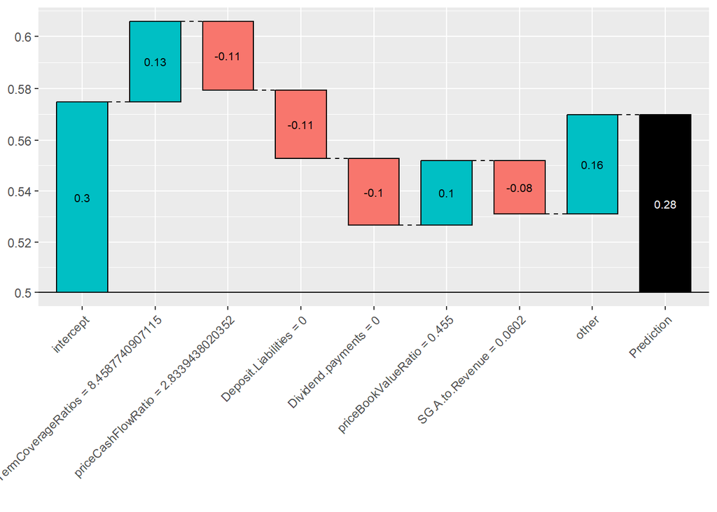

```r
# Create explainer for sample 2000
showWaterfall(bst_final, explainer, dtest, as.matrix(test_data[, 1:220]) ,2000, type = "binary", threshold = 0.07)
```

```
##
##
## Extracting the breakdown of each prediction...
##
##
## DONE!
##
## Actual:  1
## Prediction:  0.7976228
## Weight:  1.371503
## Breakdown
##                              intercept          Issuance..buybacks..of.shares
##                             0.30175693                             0.13472576
## Weighted.Average.Shares.Diluted.Growth                      Dividend.payments
##                             0.13465507                             0.10811036
##                    Deposit.Liabilities                shortTermCoverageRatios
##                            -0.10770354                             0.08938214
##                            Debt.Growth                                  other
##                             0.08455115                             0.62602492
```

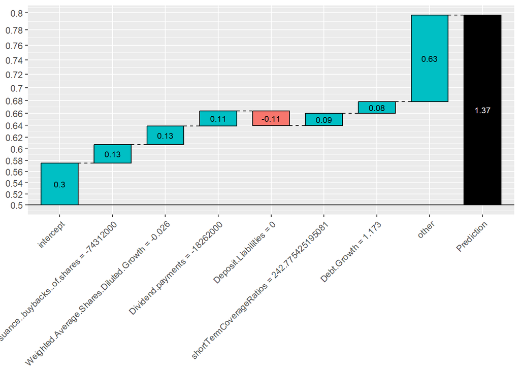

### Compare methods

We can compare different models by plotting their auc curves. For this we will compare our first model against our final balanced model.

```r
# Calculate first model ROC
roc1 = roc(test_data$class, boost_preds_1)
# Calculate final model ROC
roc2 = roc(test_data$class, boost_preds_bal)
```

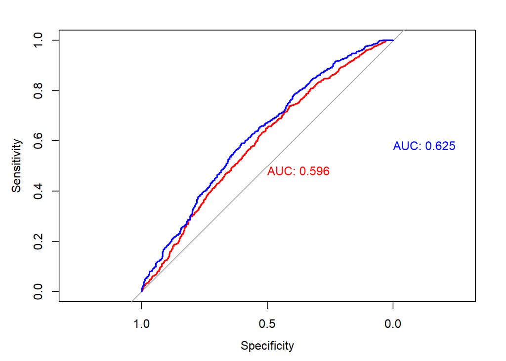

```r
# Print initial model AUC
plot.roc(roc1, print.auc = TRUE, col = "red", print.auc.col = "red")
# Print final model AUC
plot.roc(roc2, print.auc = TRUE, print.auc.x = 0, print.auc.y = 0.6, col ="blue", print.auc.col = "blue", add = TRUE)
```